# OHI-Northeast: Livelihoods

## Coastal wages

We already cleaned up this NOEP dataset above and can just create a new dataframe, `coast_wages` by selecting the `rgn_wages` column rather than `rgn_employment`. Wages are also standardized by total employment to give us a measure of wages per capita as opposed to total wages.

```r
coast_wages <- bind_rows(state_data, county_data) %>%
  mutate(wages_per_job = rgn_wages/rgn_employment) %>%
  select(state, year, rgn_id, rgn_name, wages_per_job)

write.csv(coast_wages, file.path(dir_calc, "layers/le_coast_wages.csv"))
```

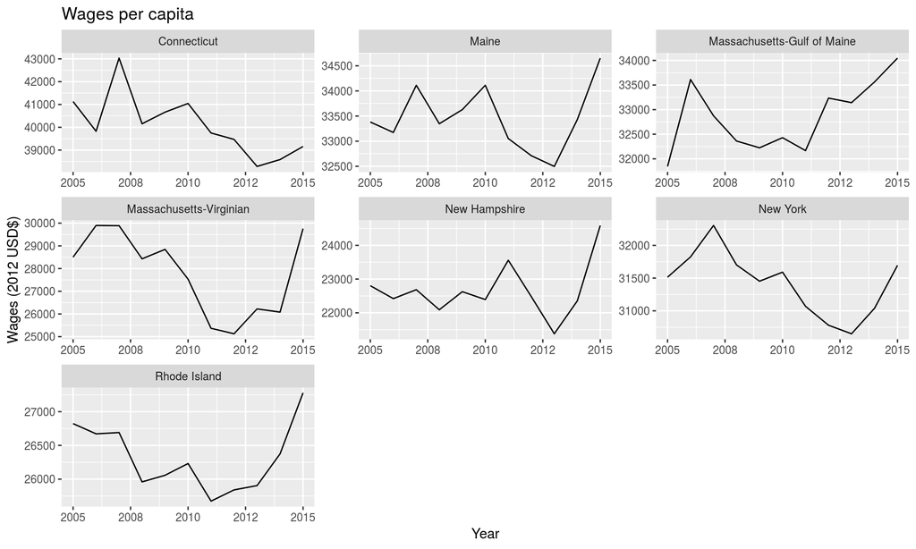

```r
ggplot(coast_wages, aes(x = year, y = wages_per_job)) +
  geom_line() +
  ylab("Wages (2012 USD$)") +
  facet_wrap(~ rgn_name, scales = "free") +
  ggtitle("Wages per capita") +
  xlab("Year")
```

## Reference point

```r
wages_cst_ref <- coast_wages %>%
  arrange(year) %>%
  group_by(rgn_id) %>%
  mutate(coast_wages_1yr = rollapply(wages_per_job, 1, FUN=mean, align = "right", na.rm=F, partial = T),
         coast_wages_prev_1yr = lag(coast_wages_1yr, n = 1)) %>%
  select(state, year, rgn_id, rgn_name, ref = coast_wages_prev_1yr)

write.csv(wages_cst_ref, file.path(dir_calc, "layers/le_coast_wages_ref.csv"))
```

**Wages per job directly related to ocean in coastal counties**

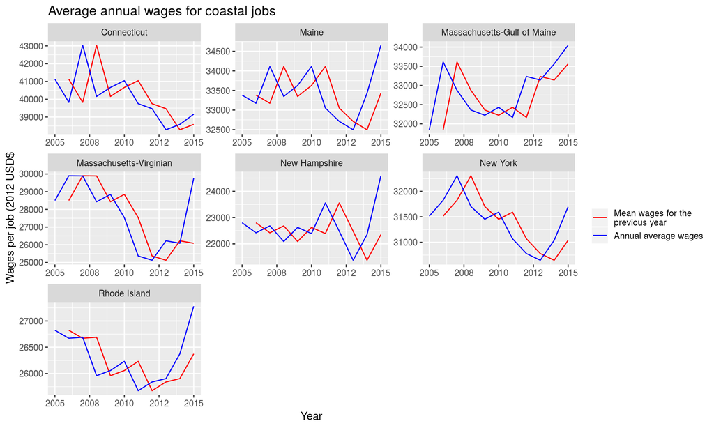

```r
c <- coast_wages %>%
  left_join(wages_cst_ref) %>%
  select(rgn_id, year, wages_per_job, ref, rgn_name) %>%
  gather(data, wages, -rgn_id,-year, -rgn_name)

ggplot(c, aes(x = year, y = wages, color = data)) +
  geom_line() +
  facet_wrap(~rgn_name, scales = "free") +
  ylab("Wages per job (2012 USD$") +
  xlab("Year") +
  ggtitle("Average annual wages for coastal jobs") +
  scale_color_manual(" ", labels = c("Mean wages for the \nprevious year","Annual average wages"), values = c("red", "blue"))
```

# Setting targets

Using Bureau of Labor Statistics data, we can get the nationwide average job growth and use this as our target for coastal job growth.

```r
#devtools::install_github("keberwein/blscrapeR")
library(blscrapeR)
#read in API access key that is saved on Mazu
blsKey <- read_rtf(file.path(dir_M,'git-annex/neprep/keys/BureauofLaborStatistics.rtf'))
set_bls_key(blsKey, overwrite=TRUE)
```

```
## [1] "4c836433dd7749e8ad03bda85acf1342"
```

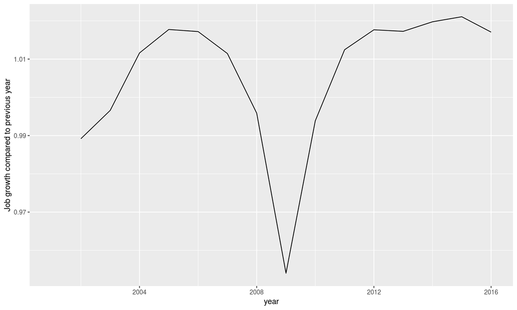

```r
us_employment <- bls_api("ENUUS00010010",
              startyear = 2001, endyear = 2016, registrationKey = "BLS_KEY", annualaverage=TRUE) %>%
  as.data.frame() %>%
  filter(periodName == "Annual") %>%
  select(year, us_jobs = value) %>%
  arrange(year) %>%
  mutate(us_jobs_1yr = rollapply(us_jobs, 1, FUN=mean, align = "right", na.rm=F, partial = T),
         us_jobs_prev_1yr = lag(us_jobs_1yr, n = 1),
         us_job_growth = us_jobs/us_jobs_prev_1yr) %>%
  select(year, us_job_growth)

write.csv(us_employment, file.path(dir_calc, "layers/le_usa_jobs.csv"))

ggplot(us_employment, aes(x = year, y = us_job_growth)) +
  geom_line() +
  ylab("Job growth compared to previous year")
```

# Results

While this is done in the OHI toolbox, the calculated results are duplicated here.

## Jobs

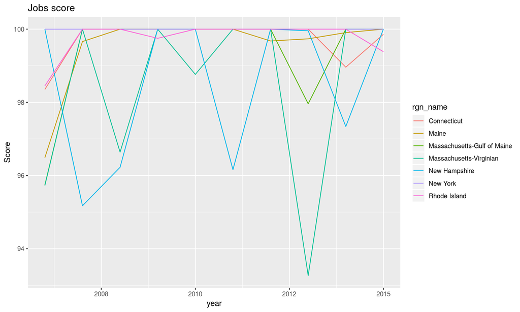

```r
  ##combining the employment data and calculating the change compared to reference period

  ##coastal jobs
  cst_jobs <- coast_jobs %>%
    rename(coast_jobs = rgn_employment) %>%
    left_join(jobs_cst_ref) %>%    #join with the reference point data
    filter(!is.na(ref)) %>%     #remove years with NA for mean jobs (same as removing years pre-2010)
    rename(coast_mean_jobs = ref) %>%
    mutate(cst_chg = coast_jobs/coast_mean_jobs)

  #combine coastal and state data, calculate jobs scores
  jobs_score <- cst_jobs %>%
    left_join(us_employment) %>%        #add in the national statistics for job growth
    mutate(job_score = ifelse(cst_chg >= us_job_growth, 1, cst_chg/us_job_growth)*100) %>%
    select(rgn_id, year, job_score) %>%
    left_join(rgn_data)

  ggplot(jobs_score, aes(x = year, y = job_score, color = rgn_name)) +
    geom_line() +
      ylab("Score")+
      ggtitle("Jobs score")
```

## Wages

According to the Federal Reserve, the *Nominal Wage Growth Target* is 3 - 3.5% annually. [EPI report explaining this in more detail](http://www.epi.org/nominal-wage-tracker/).

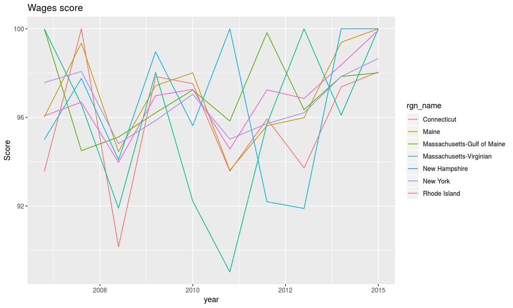

```r
  ## Wages scores
  #combining the coastal wage data and calculate the change
  cst_wages <- coast_wages %>%
    left_join(wages_cst_ref) %>%    #join with the reference point data
    filter(!is.na(ref)) %>%       #remove years with NA for wages (same as removing years pre-2010)
    rename(coast_mean_wages = ref) %>%
    mutate(cst_chg = wages_per_job/coast_mean_wages)


  #combine coastal and state data, calculate
  wages_score <- cst_wages %>%
    mutate(wages_score = ifelse(cst_chg > 1.035, 1, cst_chg/1.035)*100) %>%
    select(rgn_id, year, wages_score) %>%
    left_join(rgn_data)

    ggplot(wages_score, aes(x = year, y = wages_score, color = rgn_name)) +
    geom_line() +
      ylab("Score")+
      ggtitle("Wages score")
```

## Livelihoods status

Combine jobs and wages scores per region and divide by two.

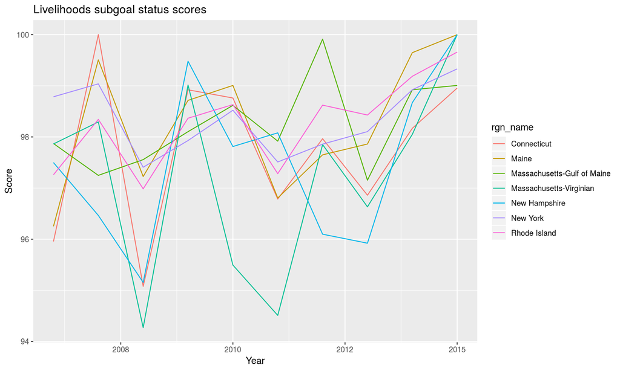

```r
  # status
  liv_status <- jobs_score %>%
    left_join(wages_score) %>%
    mutate(score = (job_score + wages_score)/2,
           dimension = "status") %>%
    select(year, region_id = rgn_id, score, dimension) %>%
  left_join(rgn_data, by = c("region_id" = "rgn_id"))

ggplot(liv_status, aes(x = year, y = score, color = rgn_name))+
  geom_line() +
  ggtitle("Livelihoods subgoal status scores") +
  ylab("Score") +
  xlab("Year")
```

# References

National Ocean Economics Program. Ocean Economic Data by Sector & Industry., ONLINE. 2012. Available: http://www.OceanEconomics.org/Market/oceanEcon.asp [3 July 2018]

Bureau of Labor Statistics, U.S. Department of Labor, Quarterly Census of Employment and Wages. 7/24/2016. http://www.bls.gov/cew/](http://www.bls.gov/cew/).